# Homework Week #3

Julia Barrone

9/26/2020

1a. I tripped up on the 3rd try.

```r
vole_vaso <- c(98,96,94,88,86,82,77,74,70,60,
           59,52,50,47,40,35,29,13,6,5)#load dataframe to R
```

1b. What is the mean, median, sd, and interquartile range of the sample? The mean is 58.05, the median is 59.5, the sd is 29.75244, and the IQR is 44.25.

```r
library(dplyr) #load dplyr to use pipes
mean(vole_vaso) #find the mean
```

```
## [1] 58.05
```

```r
median(vole_vaso) #find the median
```

```
## [1] 59.5
```

```r
sd(vole_vaso) #find the sd
```

```
## [1] 29.75244
```

```r
IQR(vole_vaso) #summary function to find quartiles
```

```
## [1] 44.25
```

1c. What is the standard error of the mean (do this with a formula!)? The standard error of the mean is 6.652848.

```r
(29.75244/sqrt(20)) #the formula to calculate se is sd of the sample divided by the square root of the sample size. I filled in those values with the information from the above questions
```

```
## [1] 6.652848
```

1d. What does the standard error of the mean tell you about our estimate of the mean values of the population of vole vassopressin?

```r
# standard error tells us how close our mean of any given sample of the population is compared with the true population mean. In other words, it measures preciseness.
```

```r
quantile(vole_vaso, probs = 0.75) #getting the upper quartile range from the example
```

```
## 75%
##  83
```

```r
sample_vole_vasco <- sample(vole_vaso, size = 10) #sampling vole_vasco and asking for a sample size of 10 values without replacement.

quantile(sample_vole_vasco, probs = 0.75) #getting the upper quartile value of my sample
```

```
##   75%
## 85.25
```

2b. Build an initial data frame for simulations with the sample sizes 5 through 20.

```r
df <- data.frame(samp_size = 5:20) #creating a new dataframe for simulations with sample sizes 5-20

df
```

```
##    samp_size
## 1          5
## 2          6
## 3          7
## 4          8
## 5          9
## 6         10
## 7         11
## 8         12
## 9         13
## 10        14
## 11        15
## 12        16
## 13        17
## 14        18
## 15        19
## 16        20
```

2c. Use this data frame to get simulated upper quartiles for each sample size. using 1,000 simulations

```r
samp_replicate <- df %>%
  # taking the new dataframe of sample sizes 5-20 and going rowwise, accounting for sample size
  rowwise(samp_size) %>%
  # replicate 1000 times but get the upper quartiles
  summarize(vole_samp = replicate(1000, quantile(sample(vole_vaso, samp_size), probs = 0.75))) #sample of dataset replicated 1000 times
samp_replicate#view samp_replicate to see the upper quartiles for each sample size
```

```
## # A tibble: 16,000 x 2
## # Groups:   samp_size [16]
##    samp_size vole_samp
##        <int>     <dbl>
##  1         5        82
##  2         5        60
##  3         5        50
##  4         5        59
##  5         5        59
##  6         5        59
##  7         5        94
##  8         5        96
##  9         5        60
## 10         5        77
## # ... with 15,990 more rows
```

2d. With a ggplot, make a guesstimate as to the best sample size for estimating the upper quartile of the population. Use whatever geom you feel makes things most easy to see. E.C. Add a red dashed line using geom_vline() or geom_hline() to show where that should be, perhaps. I am guesstimating that the best sample size for estimating the upper quartile of the population is at about 15 because the violin falls right around the upper quartile(75-100%) of our simulations on the y axis.

```r
library(ggplot2) #load ggplot

plot_values <- ggplot(data = samp_replicate,
                       mapping = aes(x = samp_size,
                                     y = vole_samp, group = samp_size))#setting up dataframe to plot data using ggplot of our simulated quartiles for each sample size. Using the mapping = aes to designate vole_samp on the x axis and samp_size on the y axis

?geom_vline #figuring out how to use vline
```

```
## starting httpd help server ... done
```

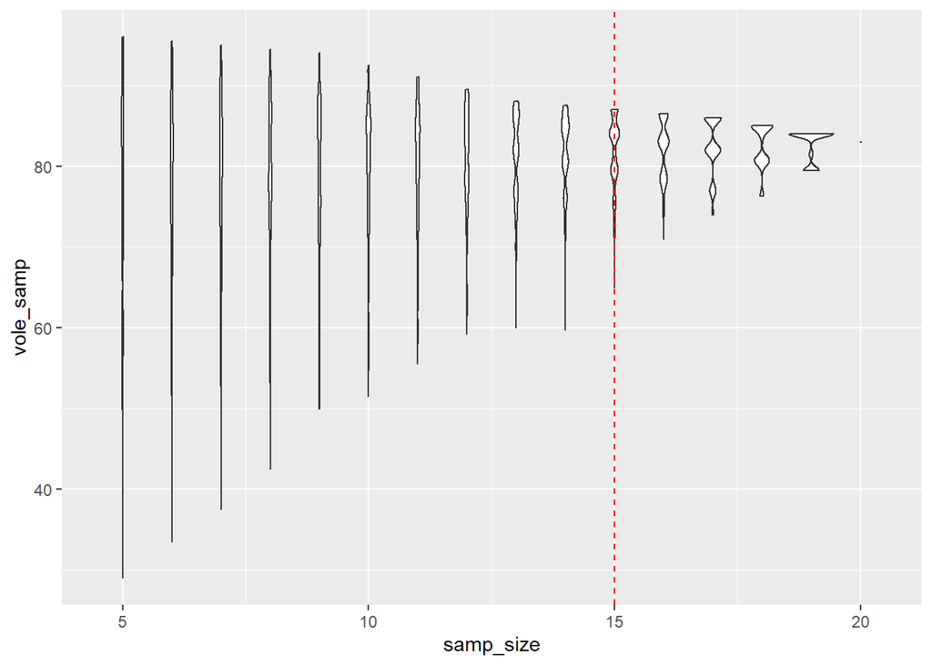

```r
plot_values +
  geom_violin() +#plotting using geom_violin because the geom_point representation was unclear(too many points).I like geom_violin because it is a combination of a density and box plot.
geom_vline(xintercept = 15, color = "red", linetype="dashed") #extra credit for showing a red, dashed line at samp size of 15
```

2e. Plot the SE of the estimate of the upper quantile by sample size. Again, what it the best way to see this? Does it level off? Is there a level you feel acceptable? Justify your answer. Does this match with what you put in 3d? This geom_point plot shows how SE of the estimate of the upper quantile decreases by sample size. Standard error decreases when sample size increases because generally, the more data you have, the closer the sample gets to the true size of the population, which we can see here. It doesn’t level off anywhere, it just shows a steady decrease. It does look like the SE is getting very close to 0 by sample size 20. This does not match my guesstimate of sample size 15 in my previous answer.

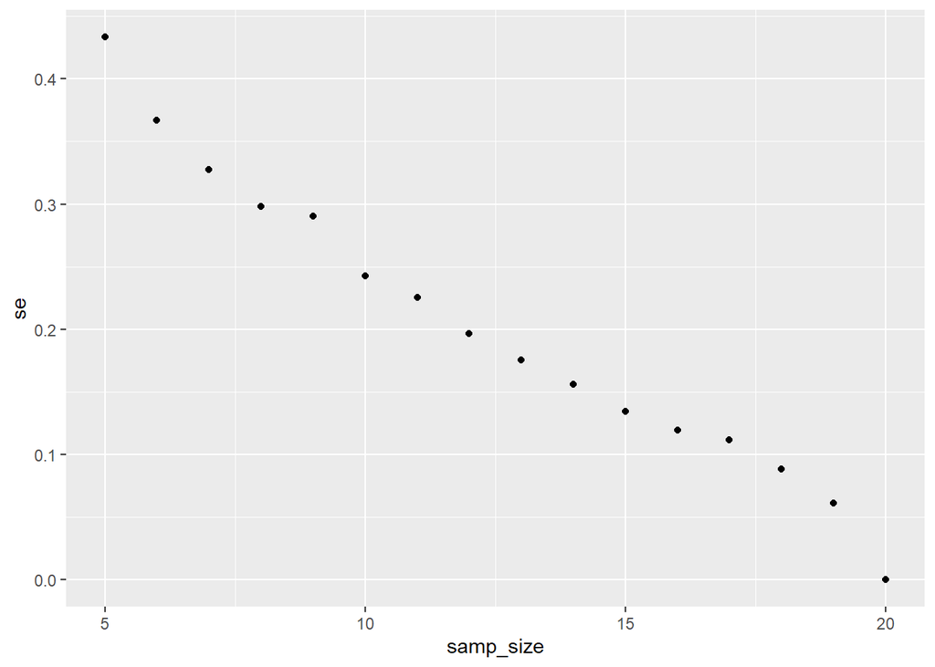

```r
se_samp_replicate <- samp_replicate %>%
  group_by(samp_size) %>%
  mutate (se = (sd(vole_samp)/sqrt(length(vole_samp))))#setting up a new dataframe of my simulated upper quartiles for my sample size but grouping by sample size. Adding a column of standard error for each sample size by using the formula for standard error

se_plot <- ggplot(data = se_samp_replicate,
                       mapping = aes(x = samp_size,
                                     y = se)) #setting up to plot with ggplot taking from the new data frame that I just created. I put samp_size on my x axis and standard error on my y axis.


se_plot +
  geom_point() #plotting to a point graph
```

```r
# standard error tells us how close our mean of any given sample of the population is compared with the true population mean. In other words, it measures preciseness.
```

3a. Some setup. Run the code below. For extra credit, look up the packages and functions used and explain what is going on here. But, that’s EC.

```r
library(dplyr) #helps with data manipulation
library(readr) #helps read rectangular data usually contained in csv, tsv and twt files
library(ggplot2) #aids in plotting
library(forcats) #helps reordering factor levels which aids in presentation


theme_set(theme_bw(base_size=12)) #theme_set is used to automaticlly apply a theme to plots that you create. This code chose a black and white theme setting text to size 12

ice <- read_csv("NH_seaice_extent_monthly_1978_2016.csv") %>%#reading our datafile and adding it to an object
  mutate(Month_Name = factor(Month_Name),#making new column in dataset, encoding a vector as a factor, in this case, "Month_Name"
   Month_Name = fct_reorder(Month_Name, Month)) #this fct_reorder is having the Month_Name column be the same order as the Month Column. So row 1 will display 11 in the month column and Nov in the Month_Name column
ice #view ice
```

```
## # A tibble: 458 x 6
##     Year Month   Day Extent Missing Month_Name
##    <dbl> <dbl> <dbl>  <dbl>   <dbl> <fct>
##  1  1978    11     1  10.7        0 Nov
##  2  1978    12     1  12.7        0 Dec
##  3  1979     2     1  15.9        0 Feb
##  4  1979     3     1  16.6        0 Mar
##  5  1979     6     1  13.1        0 Jun
##  6  1979     7     1  11.6        0 Jul
##  7  1979     9     1   7.23       0 Sep
##  8  1979    10     1   7.40       0 Oct
##  9  1980     1     1  14.2        0 Jan
## 10  1980     3     1  16.2        0 Mar
## # ... with 448 more rows
```

3b. Make a boxplot showing the variability in sea ice extent every month.

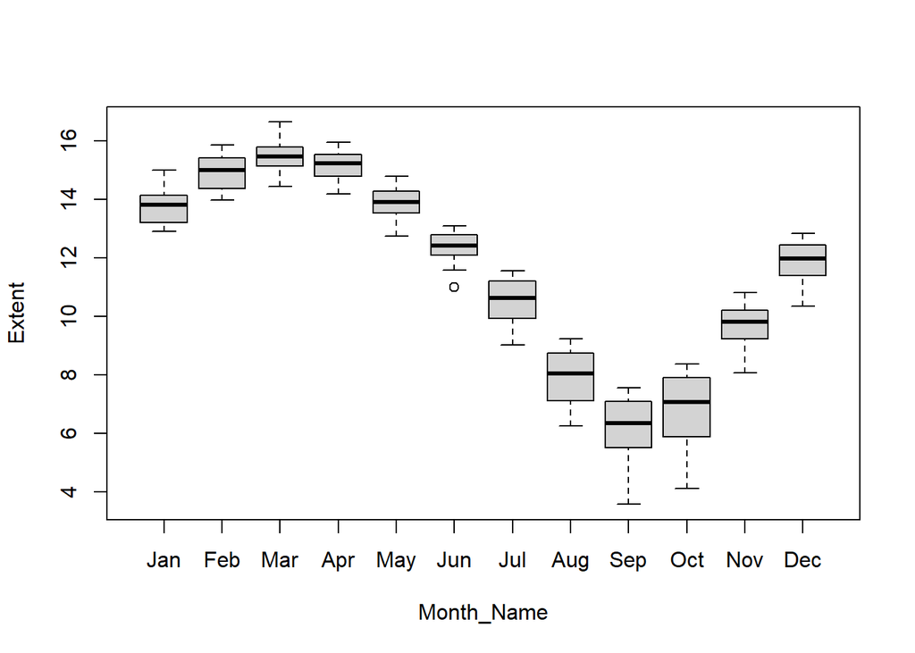

```r
boxplot(Extent ~ Month_Name, data = ice) #making a boxplot to show month on the x axis and variability in sea ice extent on the y
```

3c. Use dplyr to get the annual minimum sea ice extent. Plot minimum ice by year. What do you observe? From the plot, there are slight increases from year to year but overall, there is a clear decrease in ice extent as the years go on

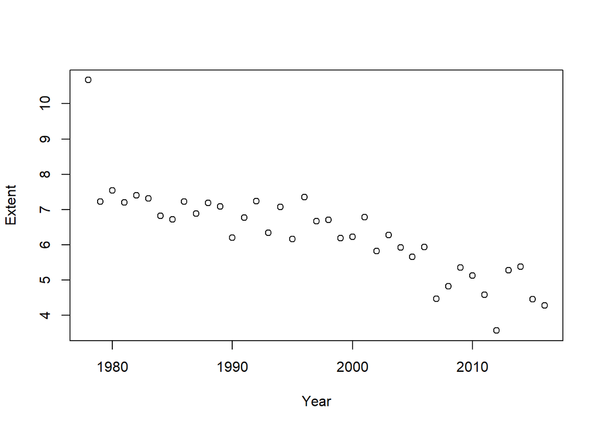

```r
library(dplyr)  #load dplyr
annual_min <- ice %>% #creating new dataframe containing minimum sea ice extent values for each year
    group_by(Year) %>% #group by year
    slice(which.min(Extent)) #index rows by integer location. remove duplicate rows and select minimum values


plot(Extent ~ Year, data = annual_min)#plot with minimum sea ice extent on the y axis and year on the x axis taking the columns from the new dataframe that I just created
```

3d. One thing that’s really cool about faceting is that you can use cut_() functions on continuos variables to make facets by groups of continuous variables. To see what I mean, try cut_interval(1:10, n = 5) See how it makes five bins of even width? We use cut_interval() or other cut functions with faceting like so facet_wrap(~cut_interval(some_variable)).